# Entrega 02 - MVP de Riesgo Operacional

Autor/a

Gonzalo Gallardo

# Objetivo

Desarrollar un Producto Mínimo Viable (MVP) en R para apoyar la revisión y priorización de riesgos y controles de Riesgo Operacional.

La herramienta permite evaluar el nivel de riesgo mediante criterios de probabilidad e impacto, revisar los controles asociados, identificar alertas y establecer una prioridad de revisión para apoyar el análisis.

# Ejecución del MVP

El análisis completo se encuentra implementado en el archivo `riesgo_operacional_mvp.R`.

[output not shown]

[output cut: 12 more lines]

```
7        R04         Errores en conciliaciones operativas            3       3
8        R05    Incumplimiento de procedimientos internos            2       4
9        R07            Errores en reportes operacionales            2       3
10       R09          Incumplimiento de plazos operativos            3       2
   puntaje_riesgo nivel_riesgo
1              20      Critico
2              20      Critico
3              20      Critico
4              16         Alto
5              15         Alto
6              15         Alto
7               9        Medio
8               8        Medio
9               6        Medio
10              6        Medio
```

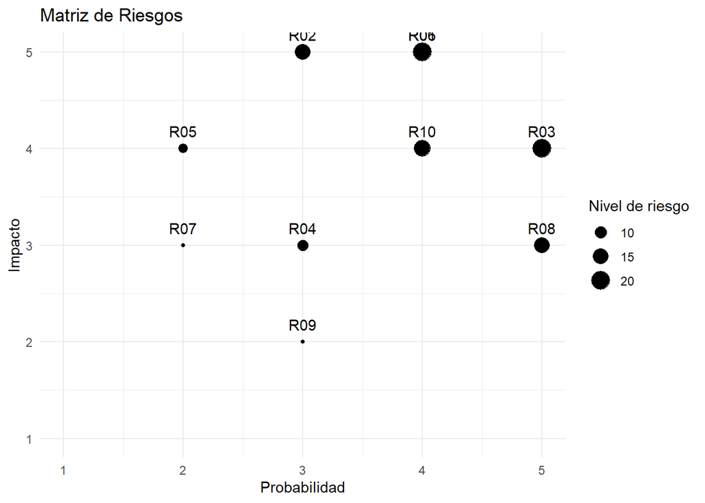

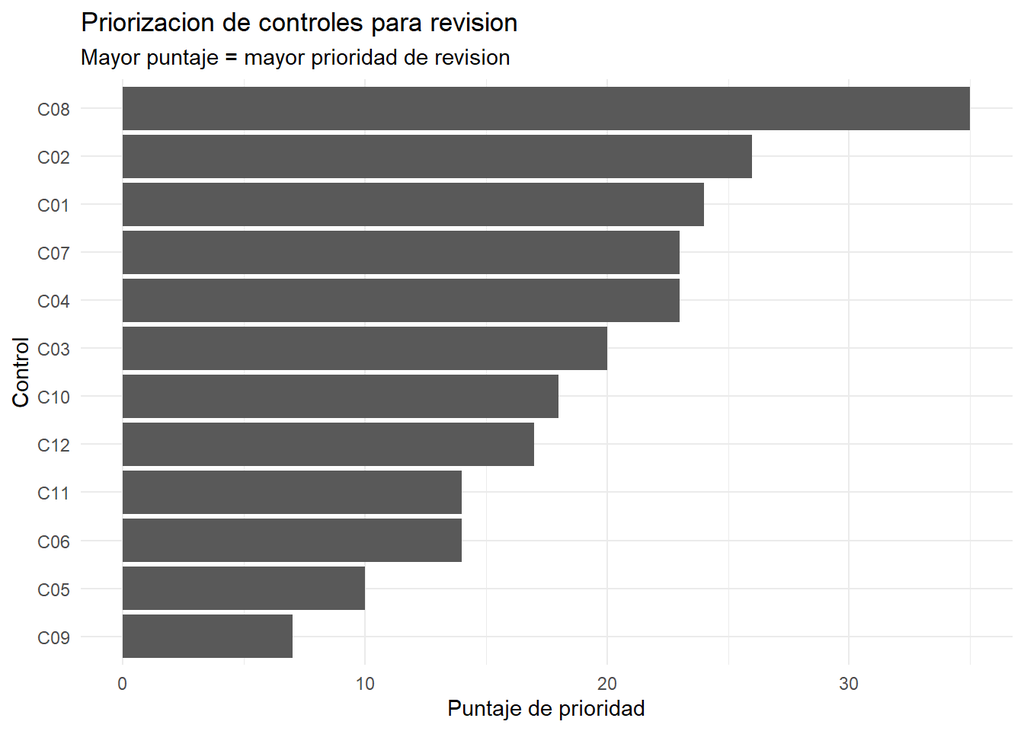

```
========================================
CONTROLES DE PRIORIDAD ALTA
========================================
# A tibble: 2 × 8
  id_riesgo id_control nivel_riesgo resultado_revision evidencia estado_plan
  <chr>     <chr>      <chr>        <chr>              <chr>     <chr>
1 R06       C08        Critico      Deficiente         No        Vencido
2 R01       C02        Critico      Con observaciones  Si        En proceso
# ℹ 2 more variables: puntaje_prioridad <dbl>, alertas <chr>

========================================
VALIDACIONES FINALES DEL MVP
========================================
OK - IDs de riesgos sin duplicados
OK - IDs de controles sin duplicados
OK - Probabilidad e impacto dentro de escala 1 a 5
OK - Puntajes de riesgo correctamente calculados
OK - Controles asociados a riesgos existentes
OK - Coherencia de planes de accion validada
OK - Resultados deficientes cuentan con plan de accion
OK - Puntajes y categorias de prioridad validos

========================================
MVP EJECUTADO CORRECTAMENTE
========================================
Riesgos analizados: 10
Controles analizados: 12
Riesgos con controles asociados: 10
Casos de prioridad Alta: 2
Casos de prioridad Media: 6
Casos de prioridad Baja: 4

Todas las validaciones del MVP fueron superadas.
```

```r
source("riesgo_operacional_mvp.R")
```

# Riesgos evaluados

La criticidad de cada riesgo se determina a partir de su probabilidad e impacto.

```r
riesgos %>%
  select(
    id_riesgo,
    descripcion_riesgo,
    probabilidad,
    impacto,
    puntaje_riesgo,
    nivel_riesgo
  ) %>%
  arrange(desc(puntaje_riesgo))
```

```
   id_riesgo                           descripcion_riesgo probabilidad impacto
1        R01 Errores en el procesamiento de transacciones            4       5
2        R03       Interrupcion de servicios tecnologicos            5       4
3        R06             Perdida de informacion relevante            4       5
4        R10           Registro incorrecto de operaciones            4       4
5        R02              Acceso no autorizado a sistemas            3       5
6        R08                  Fallas en procesos manuales            5       3
7        R04         Errores en conciliaciones operativas            3       3
8        R05    Incumplimiento de procedimientos internos            2       4
9        R07            Errores en reportes operacionales            2       3
10       R09          Incumplimiento de plazos operativos            3       2
   puntaje_riesgo nivel_riesgo
1              20      Critico
2              20      Critico
3              20      Critico
4              16         Alto
5              15         Alto
6              15         Alto
7               9        Medio
8               8        Medio
9               6        Medio
10              6        Medio
```

# Controles evaluados

Para cada riesgo se revisan los controles asociados y características relevantes para el análisis.

```r
resultado_final %>%
  select(
    id_riesgo,
    id_control,
    tipo_control,
    ejecucion,
    frecuencia,
    evidencia,
    resultado_revision,
    plan_accion,
    estado_plan
  )
```

```
# A tibble: 12 × 9
   id_riesgo id_control tipo_control ejecucion    frecuencia evidencia
   <chr>     <chr>      <chr>        <chr>        <chr>      <chr>
 1 R06       C08        Detectivo    Manual       Trimestral No
 2 R01       C02        Detectivo    Manual       Mensual    Si
 3 R01       C01        Detectivo    Manual       Diaria     Si
 4 R03       C04        Detectivo    Automatizado Diaria     Si
 5 R06       C07        Preventivo   Automatizado Diaria     Si
 6 R02       C03        Preventivo   Automatizado Mensual    No
 7 R08       C10        Detectivo    Manual       Semanal    Si
 8 R10       C12        Detectivo    Manual       Mensual    Si
 9 R05       C06        Preventivo   Manual       Trimestral No
10 R09       C11        Preventivo   Automatizado Diaria     No
11 R04       C05        Detectivo    Manual       Mensual    Si
12 R07       C09        Preventivo   Manual       Mensual    Si
# ℹ 3 more variables: resultado_revision <chr>, plan_accion <chr>,
#   estado_plan <chr>
```

# Priorización de revisión

El MVP combina el nivel de riesgo con alertas relacionadas con los controles para generar un puntaje de prioridad.

```r
resultado_final %>%
  select(
    id_riesgo,
    id_control,
    nivel_riesgo,
    alertas,
    puntaje_prioridad,
    prioridad
  ) %>%
  arrange(desc(puntaje_prioridad))
```

```
# A tibble: 12 × 6
   id_riesgo id_control nivel_riesgo alertas         puntaje_prioridad prioridad
   <chr>     <chr>      <chr>        <chr>                       <dbl> <chr>
 1 R06       C08        Critico      Riesgo critico…                35 Alta
 2 R01       C02        Critico      Riesgo critico…                26 Alta
 3 R01       C01        Critico      Riesgo critico…                24 Media
 4 R03       C04        Critico      Riesgo critico                 23 Media
 5 R06       C07        Critico      Riesgo critico                 23 Media
 6 R02       C03        Alto         Control sin ev…                20 Media
 7 R08       C10        Alto         Revision con o…                18 Media
 8 R10       C12        Alto         Control manual                 17 Media
 9 R05       C06        Medio        Control sin ev…                14 Baja
10 R09       C11        Medio        Control sin ev…                14 Baja
11 R04       C05        Medio        Control manual                 10 Baja
12 R07       C09        Medio        Control manual                  7 Baja
```

# Resumen de prioridades

```r
resultado_final %>%
  count(prioridad)
```

```
# A tibble: 3 × 2
  prioridad     n
  <chr>     <int>
1 Alta          2
2 Baja          4
3 Media         6
```

# Matriz de riesgos

La matriz permite visualizar la relación entre probabilidad e impacto de los riesgos analizados.

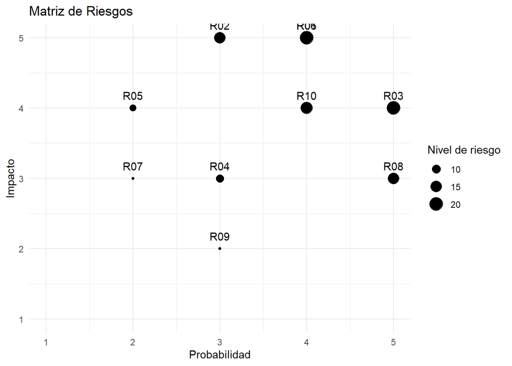

```r
print(matriz_riesgos)
```

# Priorización de controles

El siguiente gráfico permite visualizar los controles que presentan una mayor prioridad de revisión.

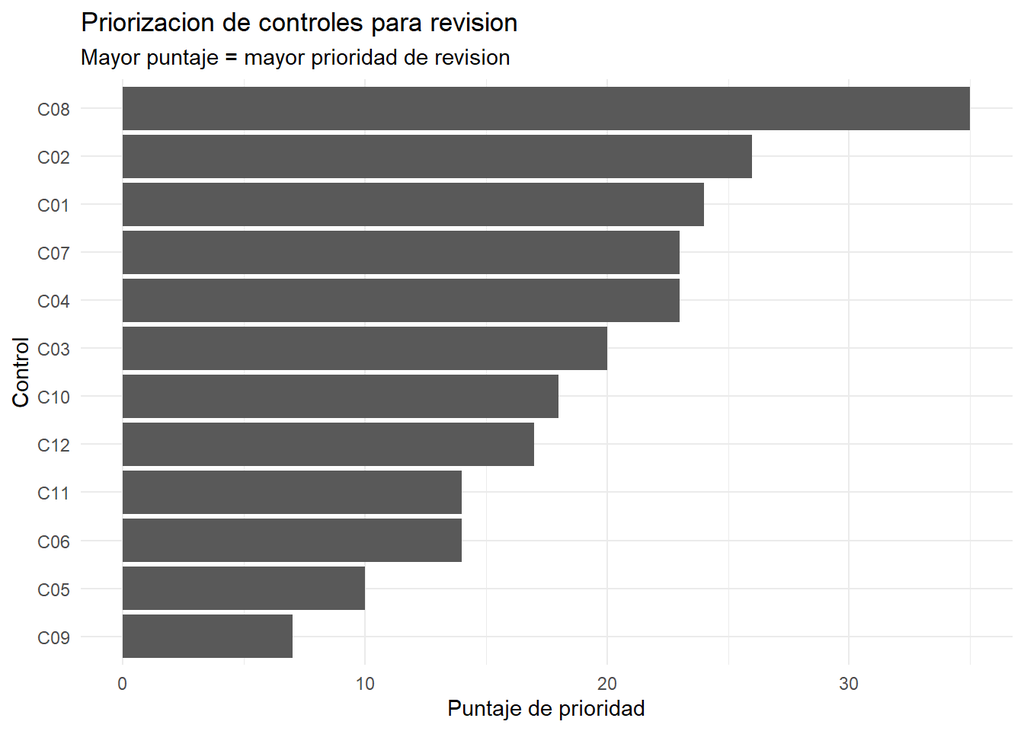

```r
print(grafico_prioridad)
```

# Validación riesgo-control

Se verifica si existen riesgos que no cuenten con controles asociados.

```r
riesgos %>%
  anti_join(
    controles %>% distinct(id_riesgo),
    by = "id_riesgo"
  )
```

```
[1] id_riesgo          descripcion_riesgo probabilidad       impacto
[5] puntaje_riesgo     nivel_riesgo
<0 rows> (or 0-length row.names)
```

# Conclusión

El MVP permite sistematizar la revisión inicial de riesgos y controles de Riesgo Operacional.

La herramienta calcula la criticidad de los riesgos mediante probabilidad e impacto, analiza características y resultados de los controles, genera alertas y establece una priorización de revisión.

De esta forma, el MVP permite concentrar el análisis en aquellos casos que requieren mayor atención y entrega información trazable para apoyar la toma de decisiones del analista de Riesgo Operacional.